# Prova 2 - 03/12/2023

```r
knitr::opts_chunk$set(error = T)
```

## Carregar Pacotes

```r
library(tidyverse)
library(yfR)
library(afedR3)
```

```r
library(car)
library(forecast)
library(fGarch)
```

## Questão 1

Using package afedR3, consider the financial data available in file EX_SP500-stocks.rds and load it in R. Notice that the actual market index is included as ticker ^GSPC.

After importing the dataset, filter out any row with NA values (you can use function complete.cases() or na.omit() for that).

Using arithmetic returns from the adjusted prices, what is the value of beta for stock SBUX?

R_t = + R_{M,t} + _t

```r
arquivo <- data_path('EX_SP500-stocks.rds')

df_sp500 <- readRDS(arquivo) |>
  na.omit()

df_base <- df_sp500 |>
  filter(ticker %in% c('^GSPC', 'SBUX')) |>
  mutate(ticker = str_replace(ticker, '\\^', '')) |>
  select(ref_date, ticker, ret_adjusted_prices)

df_base <- df_base |> pivot_wider(id_cols = ref_date,
                             names_from = ticker,
                             names_prefix = 'return_',
                             values_from = ret_adjusted_prices)

lm(return_SBUX ~ return_GSPC, data = df_base)
```

```
Call:
lm(formula = return_SBUX ~ return_GSPC, data = df_base)

Coefficients:
(Intercept)  return_GSPC
  0.0001972    1.0294824
```

## Questão 2

Using the the data from file EX_SP500-stocks.rds, estimate the following model for stock V:

Where parameter D_t is a dummy that takes value 1 if the weekday in time t is monday and 0 otherwise. What is the value of _2?

```r
df_base <- df_sp500 |>
  filter(ticker %in% c('^GSPC', 'V')) |>
  mutate(ticker = str_replace(ticker, '\\^', '')) |>
  select(ref_date, ticker, ret_adjusted_prices)

df_base <- df_base |> pivot_wider(id_cols = ref_date,
                             names_from = ticker,
                             names_prefix = 'return_',
                             values_from = ret_adjusted_prices)

df_base <- df_base |>
  mutate(dia_semana = wday(ref_date)) |>
  mutate(monday = if_else(dia_semana == 2, 1, 0)) |>
  mutate(monday = as.factor(monday))

lm(return_V ~
     return_GSPC + monday * return_GSPC - monday, data = df_base)
```

```
Call:
lm(formula = return_V ~ return_GSPC + monday * return_GSPC -
    monday, data = df_base)

Coefficients:
        (Intercept)          return_GSPC  return_GSPC:monday1
          0.0002442            1.0707809            0.1071487
```

## Questão 3

Based on file EX_SP500-stocks.rds, and using price and return data only for asset BA, estimate the following lagged model:

R_t = + *1 R*{M,t-1} + _t

What is the value of _1?

```r
df_base <- df_sp500 |>
  filter(ticker %in% c('^GSPC', 'BA')) |>
  mutate(ticker = str_replace(ticker, '\\^', '')) |>
  select(ref_date, ticker, ret_adjusted_prices)

df_base <- df_base |> pivot_wider(id_cols = ref_date,
                             names_from = ticker,
                             names_prefix = 'return_',
                             values_from = ret_adjusted_prices)

df_base <- df_base |>
  mutate(lag_mercado = lag(return_GSPC))

lm(return_BA ~ lag_mercado, data = df_base)
```

```
Call:
lm(formula = return_BA ~ lag_mercado, data = df_base)

Coefficients:
(Intercept)  lag_mercado
  7.708e-05   -1.222e-01
```

## Questão 4

Using the data from file EX_SP500-stocks.rds, estimate the following model for stock AFL:

Where WeekDummy _{i,t} is a dummy variable that takes value 1 if the day of the week is i (monday to friday). What is the estimated value of parameter _2?

```r
df_base <- df_sp500 |>
  filter(ticker %in% c('^GSPC', 'AFL')) |>
  mutate(ticker = str_replace(ticker, '\\^', '')) |>
  select(ref_date, ticker, ret_adjusted_prices)

df_base <- df_base |> pivot_wider(id_cols = ref_date,
                             names_from = ticker,
                             names_prefix = 'return_',
                             values_from = ret_adjusted_prices)

df_base <- df_base |>
  mutate(dia_semana = wday(ref_date)) |>
  mutate(segunda = if_else(dia_semana == 2, 1, 0),
         terca = if_else(dia_semana == 3, 1, 0),
         quarta = if_else(dia_semana == 4, 1, 0),
         quinta = if_else(dia_semana == 5, 1, 0),
         sexta = if_else(dia_semana == 6, 1, 0))

lm(return_AFL ~ return_GSPC +
     segunda +
     terca +
     quarta +
     quinta +
     sexta - 1, data = df_base)
```

```
Call:
lm(formula = return_AFL ~ return_GSPC + segunda + terca + quarta +
    quinta + sexta - 1, data = df_base)

Coefficients:
return_GSPC      segunda        terca       quarta       quinta        sexta
  9.844e-01    5.766e-04    3.893e-06   -4.234e-04   -6.091e-04    1.501e-03
```

## Questão 5

Using file EX_SP500-stocks.rds, consider the estimation of the beta model for stock VRSN. Using CRAN package car, perform a linear hypothesis test for = 0 and = 0.6. What is the p-value of the test?

```r
df_base <- df_sp500 |>
  filter(ticker %in% c('^GSPC', 'VRSN')) |>
  mutate(ticker = str_replace(ticker, '\\^', '')) |>
  select(ref_date, ticker, ret_adjusted_prices)

df_base <- df_base |> pivot_wider(id_cols = ref_date,
                             names_from = ticker,
                             names_prefix = 'return_',
                             values_from = ret_adjusted_prices)

modelo1 <- lm(return_VRSN ~ return_GSPC, data = df_base)

modelo1
```

```
Call:
lm(formula = return_VRSN ~ return_GSPC, data = df_base)

Coefficients:
(Intercept)  return_GSPC
  0.0001979    0.9935883
```

```r
lh <- linearHypothesis(modelo1, c("(Intercept) = 0", "return_GSPC   = 0.6"))
lh
```

```
Linear hypothesis test

Hypothesis:
(Intercept) = 0
return_GSPC = 0.6

Model 1: restricted model
Model 2: return_VRSN ~ return_GSPC

  Res.Df     RSS Df Sum of Sq      F    Pr(>F)
1   1256 0.24324
2   1254 0.20753  2  0.035704 107.87 < 2.2e-16 ***
---
Signif. codes:  0 '***' 0.001 '**' 0.01 '*' 0.05 '.' 0.1 ' ' 1
```

```r
lh$`Pr(>F)`
```

```
[1]           NA 5.922286e-44
```

## Questão 6

After loading the data from file EX_SP500-stocks.rds, estimate the following beta (market) model for stock JKHY:

R_t = + R_{M,t} + _t

After the estimation, perform a Durbin Watson test of serial correlation. What is the p-value of the test?

```r
library(lmtest)
df_base <- df_sp500 |>
  filter(ticker %in% c('^GSPC', 'JKHY')) |>
  mutate(ticker = str_replace(ticker, '\\^', '')) |>
  select(ref_date, ticker, ret_adjusted_prices)

df_base <- df_base |> pivot_wider(id_cols = ref_date,
                             names_from = ticker,
                             names_prefix = 'return_',
                             values_from = ret_adjusted_prices)

modelo1 <- lm(return_JKHY ~ return_GSPC, data = df_base)

dwtest(modelo1)
```

```
    Durbin-Watson test

data:  modelo1
DW = 2.0186, p-value = 0.6314
alternative hypothesis: true autocorrelation is greater than 0
```

## Questão 7

Consider the data in file EX_SP500-stocks.rds for two stocks: DE and SBUX. Based on the return dataset, estimate the following linear model:

R_{DE,t} = + *1 R*{SBUX,t} + _t

What is the value of _1?

```r
df_base <- df_sp500 |>
  filter(ticker %in% c('DE', 'SBUX')) |>
  select(ref_date, ticker, ret_adjusted_prices)

df_base <- df_base |> pivot_wider(id_cols = ref_date,
                             names_from = ticker,
                             names_prefix = 'return_',
                             values_from = ret_adjusted_prices)

lm(return_DE ~ return_SBUX, data = df_base)
```

```
Call:
lm(formula = return_DE ~ return_SBUX, data = df_base)

Coefficients:
(Intercept)  return_SBUX
  0.0008499    0.5004423
```

## Questão 8

Load the data from file EX_SP500-stocks.rds and keep all rows for the following tickers: ZBH, ULTA, V, BA, KEY, SPG, NDAQ, NTRS, FCX, DGX, NLOK, HES, PEP, JKHY, TWTR, DE, CMI. Using package lmtest, perform the Durbin Watson test for the market model of each stock. How many of the 17 stocks reject the null hypothesis of serial correlation at 5%?

```r
tickers <- c('ZBH', 'ULTA', 'V', 'BA', 'KEY', 'SPG', 'NDAQ',
             'NTRS', 'FCX', 'DGX', 'NLOK', 'HES', 'PEP',
             'JKHY', 'TWTR', 'DE', 'CMI', '^GSPC')

df_base <- df_sp500 |>
  filter(ticker %in% tickers) |>
  mutate(ticker = str_replace(ticker, '\\^', '')) |>
  select(ref_date, ticker, ret_adjusted_prices)

df_base <- df_base |> pivot_wider(id_cols = ref_date,
                             names_from = ticker,
                             names_prefix = 'return_',
                             values_from = ret_adjusted_prices)

# ativos a modelar
ativos <- names(df_base)[-c(1,2)]

lista_modelos <- list()

# gerar modelo apra cada ativo
for (i in 1:length(ativos)){

  ativo <- ativos[i]

  lista_modelos[[i]] <- lm(unlist(df_base[paste(ativo)]) ~
                                df_base$return_GSPC)

}

# inserir nome na lista
names(lista_modelos) <- ativos

x <- numeric()
# durbin watson test para todos
for (i in 1:length(ativos)){

  x <- append(x, dwtest(lista_modelos[[i]])$p.value)
}

# quantidade maior que 0.05
x[x <=0.05] |> length()
```

```
[1] 2
```

## Questão 9

Again using data from file EX_SP500-stocks.rds, filter the dataset by removing the following tickers: ORLY, ZBH, LEN, WY, GOOGL, JKHY, D, TWTR, NLOK, SBUX, NDAQ, V, CINF, TRGP, TGT, SPG. With the resulting dataframe, calculate the beta (market model) coefficient for all available remaining stocks. What is the average value of Beta?

```r
remover_tickers <- c('ORLY', 'ZBH', 'LEN', 'WY', 'GOOGL', 'JKHY', 'D', 'TWTR',
                      'NLOK', 'SBUX', 'NDAQ', 'V', 'CINF', 'TRGP', 'TGT', 'SPG')

df_base <- df_sp500 |>
  filter(!ticker %in% remover_tickers) |>
  mutate(ticker = str_replace(ticker, '\\^', '')) |>
  select(ref_date, ticker, ret_adjusted_prices)

df_base <- df_base |> pivot_wider(id_cols = ref_date,
                             names_from = ticker,
                             names_prefix = 'return_',
                             values_from = ret_adjusted_prices)

# ativos a modelar
ativos <- names(df_base)[-c(1,2)]

beta <- numeric()
# gerar modelo apra cada ativo
for (i in 1:length(ativos)){

  ativo <- ativos[i]

  modelo <- lm(unlist(df_base[paste(ativo)]) ~
                                df_base$return_GSPC)

  beta <- append(beta, modelo$coefficients[2])

}

mean(beta)
```

```
[1] 1.074346
```

## Questão 10

Using the information from file EX_SP500-stocks.rds and keeping data only for tickers LEN, VRSN, FCX, SBUX, HES, PEP, DE, DGX, ORLY, TRGP, V, KEY, GOOGL, NDAQ, D, JKHY, TWTR, BA, NTRS estimate the beta model for all remaining stocks. What is the minimum value of alpha for all 19 stocks?

```r
tickers <- c('LEN', 'VRSN', 'FCX', 'SBUX', 'HES', 'PEP', 'DE',
              'DGX', 'ORLY', 'TRGP', 'V', 'KEY', 'GOOGL', 'NDAQ',
              'D', 'JKHY', 'TWTR', 'BA', 'NTRS', '^GSPC')

df_base <- df_sp500 |>
  filter(ticker %in% tickers) |>
  mutate(ticker = str_replace(ticker, '\\^', '')) |>
  select(ref_date, ticker, ret_adjusted_prices)

df_base <- df_base |> pivot_wider(id_cols = ref_date,
                             names_from = ticker,
                             names_prefix = 'return_',
                             values_from = ret_adjusted_prices)

# ativos a modelar
ativos <- names(df_base)[-c(1,2)]

alfa <- numeric()
# gerar modelo apra cada ativo
for (i in 1:length(ativos)){

  ativo <- ativos[i]

  modelo <- lm(unlist(df_base[paste(ativo)]) ~
                                df_base$return_GSPC)

  alfa <- append(alfa, modelo$coefficients[1])

}

min(alfa)
```

```
[1] -0.0005929478
```

## Questão 11

Consider the following GLM model:

E ( P(R *t > 0) ) = g (+ R*{Mkt,t} )

where P(R _t > 0) is the probability that the return of a particular stock is higher than 0 and g() is the logit function. Estimate this GLM model using R and, looking the result for stock PEP, what is the value of ?

```r
tickers <- c('PEP', '^GSPC')

df_base <- df_sp500 |>
  filter(ticker %in% tickers) |>
  mutate(ticker = str_replace(ticker, '\\^', '')) |>
  select(ref_date, ticker, ret_adjusted_prices)

df_base <- df_base |> pivot_wider(id_cols = ref_date,
                             names_from = ticker,
                             names_prefix = 'return_',
                             values_from = ret_adjusted_prices)

# returno maior que 0
df_base <- df_base |>
  mutate(retorno_positivo = ifelse(return_PEP > 0, 1, 0))

lm(return_PEP ~ return_GSPC, df_base)
```

```
Call:
lm(formula = return_PEP ~ return_GSPC, data = df_base)

Coefficients:
(Intercept)  return_GSPC
  0.0003204    0.6960114
```

```r
glm(data = df_base,
              formula = retorno_positivo ~ return_GSPC ,
              family = binomial(link = "logit"))
```

```
Call:  glm(formula = retorno_positivo ~ return_GSPC, family = binomial(link = "logit"),
    data = df_base)

Coefficients:
(Intercept)  return_GSPC
     0.1688      87.4791

Degrees of Freedom: 1255 Total (i.e. Null);  1254 Residual
Null Deviance:      1730
Residual Deviance: 1510     AIC: 1514
```

## Questão 12

Using set.seed = 46 and function arima.sim, simulate 395 observations of the following ARMA model:

y_t = 0.3 y_{t-1} + -0.15 *{t-1} +* {t}

_{t} N(0, var = 1.96)

How many observations of the simulated model are higher than 0?

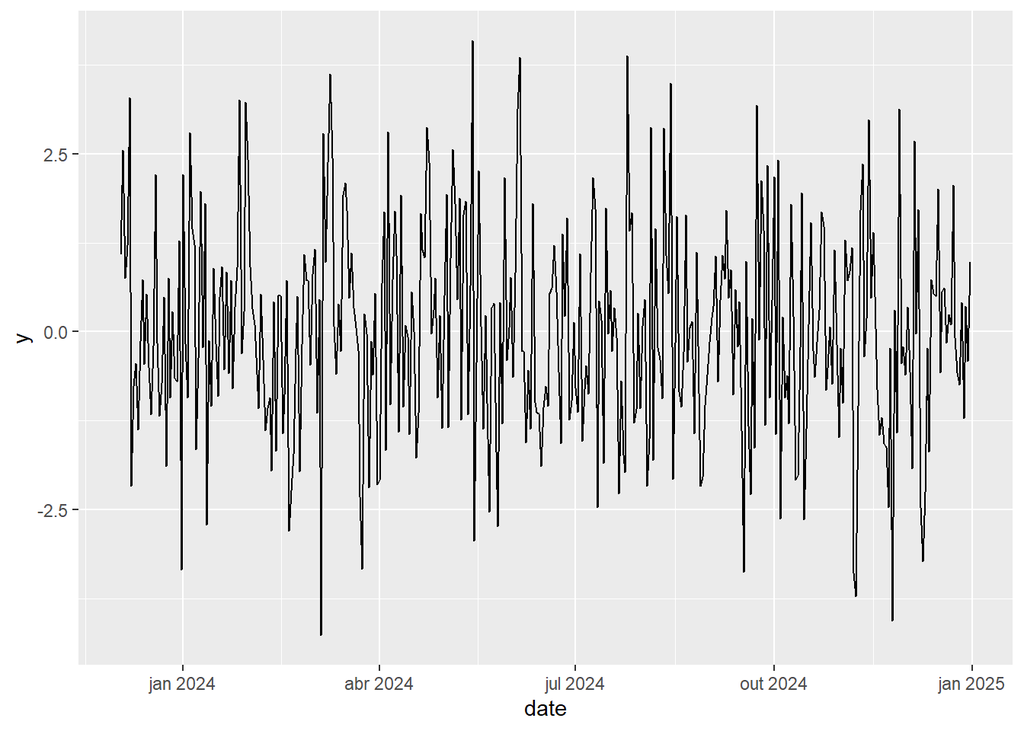

```r
set.seed(46)

# set number of observations
n_T <- 395

# set model's parameters
arima_param <- list(ar = 0.3,
                    ma = -0.15)
my_sd <- sqrt(1.96)

# simulate model
my_ts <- stats::arima.sim(
  n = n_T,
  model = arima_param,
  sd = my_sd
)

# set df
temp_df <- dplyr::tibble(
  y = unclass(my_ts),
  date = Sys.Date() + 1:n_T
)

p <- ggplot(temp_df, aes(x = date, y = y)) +
  geom_line(linewidth = 0.5)

p
```

```r
temp_df |> filter(y > 0) |> nrow()
```

```
[1] 195
```

## Questão 13

Again, using set.seed = 2 and function arima.sim, simulate 473 observations of the following ARMA model:

y_t = 0.2 y_{t-1} + -0.15 *{t-1} +* {t}

_{t} N(0, var = 2.25)

Based on this simulated time series, estimate an ARIMA(1,0,1) model. What is the value of the AR parameter?

```r
set.seed(2)

# set number of observations
n_T <- 473

# set model's parameters
arima_param <- list(ar = 0.2,
                    ma = -0.15)
my_sd <- sqrt(2.25)

# simulate model
my_ts <- stats::arima.sim(
  n = n_T,
  model = arima_param,
  sd = my_sd
)

stats::arima(
  my_ts,
  order = c(1,0,1))
```

```
Call:
stats::arima(x = my_ts, order = c(1, 0, 1))

Coefficients:
         ar1      ma1  intercept
      0.4911  -0.4280     0.1251
s.e.  0.3263   0.3373     0.0803

sigma^2 estimated as 2.418:  log likelihood = -880,  aic = 1768
```

## Questão 14

Load the data from file EX_SP500-stocks.rds and, based on the information for stock DGX, estimate an ARIMA(2, 0, 2) model for the returns of adjusted prices. What is the sum of all AR parameters?

```r
tickers <- c('DGX')

df_base <- df_sp500 |>
  filter(ticker %in% tickers) |>
  mutate(ticker = str_replace(ticker, '\\^', '')) |>
  select(ref_date, ticker, ret_adjusted_prices)

df_base <- df_base |> pivot_wider(id_cols = ref_date,
                             names_from = ticker,
                             names_prefix = 'return_',
                             values_from = ret_adjusted_prices)

modelo_arima <- stats::arima(
  df_base$return_DGX,
  order = c(2, 0, 2))

modelo_arima$coef[1:2] |> sum()
```

```
[1] -0.3434626
```

## Questão 15

Again, load the data from file EX_SP500-stocks.rds and, based on the information for stock D, estimate an ARIMA(4, 0, 2) model for the returns of adjusted prices. Based on the estimated model, what is the forecasted return for t+1

```r
tickers <- c('D')

df_base <- df_sp500 |>
  filter(ticker %in% tickers) |>
  mutate(ticker = str_replace(ticker, '\\^', '')) |>
  select(ref_date, ticker, ret_adjusted_prices)

df_base <- df_base |> pivot_wider(id_cols = ref_date,
                             names_from = ticker,
                             names_prefix = 'return_',
                             values_from = ret_adjusted_prices)

modelo_arima <- stats::arima(
  df_base$return_D,
  order = c(4, 0, 2))

modelo_arima
```

```
Call:
stats::arima(x = df_base$return_D, order = c(4, 0, 2))

Coefficients:
          ar1     ar2      ar3      ar4     ma1      ma2  intercept
      -0.6559  0.1390  -0.0611  -0.2428  0.5696  -0.1872      1e-04
s.e.   0.1145  0.1142   0.0350   0.0287  0.1176   0.1039      3e-04

sigma^2 estimated as 0.0002399:  log likelihood = 3452.22,  aic = -6888.44
```

```r
forecast::forecast(modelo_arima, h = 1)
```

```
     Point Forecast       Lo 80      Hi 80       Lo 95      Hi 95
1257    -0.00717848 -0.02702729 0.01267033 -0.03753461 0.02317765
```

## Questão 16

Use function forecast::auto.arima to estimate the best model for the adjusted returns of stock WY from file EX_SP500-stocks.rds. Using the AIC criteria (see input ic in auto.arima). What is the optimal lag for the AR parameter?

```r
tickers <- c('WY')

df_base <- df_sp500 |>
  filter(ticker %in% tickers) |>
  mutate(ticker = str_replace(ticker, '\\^', '')) |>
  select(ref_date, ticker, ret_adjusted_prices)

df_base <- df_base |> pivot_wider(id_cols = ref_date,
                             names_from = ticker,
                             names_prefix = 'return_',
                             values_from = ret_adjusted_prices)

forecast::auto.arima(
  x = df_base$return_WY,
  ic = 'aic')
```

```
Series:
ARIMA(2,0,2) with zero mean

Coefficients:
          ar1      ar2     ma1     ma2
      -1.7054  -0.9059  1.5869  0.7980
s.e.   0.0269   0.0290  0.0384  0.0445

sigma^2 = 0.000546:  log likelihood = 2937.68
AIC=-5865.37   AICc=-5865.32   BIC=-5839.69
```

## Questão 17

Load the data from file EX_B3-stocks.rds and keep all data for the following assets: AZUL4.SA, RAIL3.SA, ENGI11.SA, SANB11.SA, EMBR3.SA, USIM5.SA, JBSS3.SA, ENBR3.SA.Be aware that youll need to create the return column. Using the filtered data, estimate the best arima model for each asset with function forecast::auto.arima using a maximum order (input max.order) of 3. How many stocks have AR lag order equal to 0?

```r
arquivo <- data_path('EX_B3-stocks.rds')

df_b3 <- readRDS(arquivo)

tickers <- c('AZUL4.SA', 'RAIL3.SA', 'ENGI11.SA', 'SANB11.SA',
             'EMBR3.SA', 'USIM5.SA', 'JBSS3.SA', 'ENBR3.SA')

df_base <- df_b3 |>
  filter(ticker %in% tickers) |>
  mutate(ticker = str_replace(ticker, '\\^', '')) |>
  select(ref_date, ticker, ret_adjusted_prices)

df_base <- df_base |> pivot_wider(id_cols = ref_date,
                             names_from = ticker,
                             names_prefix = 'return_',
                             values_from = ret_adjusted_prices)


# ativos a modelar
ativos <- names(df_base)[-c(1)]

modelos_arima <- list()

# gerar modelo apra cada ativo
for (i in 1:length(ativos)){

  ativo <- ativos[i]

  modelo <- forecast::auto.arima(df_base[, paste(ativo)], max.order = 3)

  modelos_arima[[i]] <- modelo$coef
}

names(modelos_arima) <- ativos

modelos_arima
```

```
$return_AZUL4.SA
numeric(0)

$return_EMBR3.SA
numeric(0)

$return_ENBR3.SA
          ma1     intercept
-0.1417121494  0.0007449326

$return_ENGI11.SA
          ar1           ar2           ar3     intercept
-0.1079378493  0.0552655398 -0.0676458054  0.0008297237

$return_JBSS3.SA
         ma1    intercept
-0.166820167  0.001461429

$return_RAIL3.SA
        ar1         ar2
-0.21188726  0.02781816

$return_SANB11.SA
       ar1        ar2        ma1        ma2
-1.6798142 -0.8137731  1.6103189  0.7249768

$return_USIM5.SA
numeric(0)
```

## Questão 18

```r
tickers <- c('LREN3.SA', 'BBSE3.SA', 'SULA11.SA',
             'ENGI11.SA', 'MRFG3.SA', 'EMBR3.SA', 'QUAL3.SA')

df_base <- df_b3 |>
  filter(ticker %in% tickers) |>
  mutate(ticker = str_replace(ticker, '\\^', '')) |>
  select(ref_date, ticker, ret_adjusted_prices)

df_base <- df_base |> pivot_wider(id_cols = ref_date,
                             names_from = ticker,
                             names_prefix = 'return_',
                             values_from = ret_adjusted_prices)


# ativos a modelar
ativos <- names(df_base |> select(-ref_date))

modelos_arima <- list()

# gerar modelo apra cada ativo
for (i in 1:length(ativos)){

  ativo <- ativos[i]

  modelo <- forecast::auto.arima(df_base[, paste(ativo)], max.order = 6)

  x <- forecast::forecast(modelo, h = 1)

  x <- x$mean

  modelos_arima[[i]] <- x[1]
}

names(modelos_arima) <- ativos

modelos_arima[which.max(modelos_arima)]
```

```
$return_MRFG3.SA
[1] 0.004164734
```

## Questão 19

Consider the following ARMA-GARCH process:

$$\begin{aligned}
y _t =& + 0.1 y_{t-1} + -0.05 \epsilon_{t-1} + \epsilon _t \\
\epsilon _t \sim& N \left(0, h _t \right) \\
h _t =& 0.0001 + 0.1 \epsilon ^2 _{t-1}+ 0.8 h_{t-1}
\end{aligned}$$

Using set.seed = 17, simulate 754 observations of the model. What is the result for the last simulated value in the series? Tip: Use set.seed() in code line right before calling garchSim().

```r
# set list with model spec
my_sim_garch = list(
  omega = 0.0001,
  alpha = 0.1,
  beta = 0.8,
  mu = 0,
  ar = 0.1,
  ma = -0.05

)

# set garch spec
spec = fGarch::garchSpec(
  model = my_sim_garch
)

set.seed(17)
x <- garchSim(spec = spec, n = 754)

x |> last()
```

```
          garch
[1,] 0.05145553
```

## Questão 20

Consider the following ARMA-GARCH process:

$$\begin{aligned}
y _t =& + 0.15 y_{t-1} + -0.15 \epsilon_{t-1} + \epsilon _t \\
\epsilon _t \sim& N \left(0, h _t \right) \\
h _t =& 0.0001 + 0.1 \epsilon ^2 _{t-1}+ 0.7 h_{t-1}
\end{aligned}$$

Using set.seed = 52, do 120 simulations of the process for 757 time periods. Looking at the simulated value at time 344 for all simulations, what is the maximum found value across all simulations? Tip: Make sure set.seed is used after calling garchSpec(). Somehow this function, garchSpec(), is using something random and messes up the queue needed for solving the exercise.

```r
spec = garchSpec(model = list(
  ar = 0.15,
  ma = -0.15,
  omega = 0.0001,
  alpha = 0.1,
  beta = 0.7
))
nsim <- 120
sim <- list()

set.seed(52)

for(i in 1:nsim){
  sim[[i]] <- garchSim(spec, n = 757)
}

max(sapply(sim, "[[", 344))
```

```
[1] 0.05268594
```

## Questão 21

Using package fGarch, estimate a ARMA(1,1)-GARCH(1,1) model for the returns of stock ORLY, available in file EX_SP500-stocks.rds. What is the value of the ARCH coefficient (alpha1)?

```r
arquivo <- data_path('EX_SP500-stocks.rds')

df_base <- readRDS(arquivo) |>
  na.omit() |>
  filter(ticker == 'ORLY')

#estimate garch model
my_garchfit <- fGarch::garchFit(
  data = df_base$ret_adjusted_prices,
  formula = ~ arma(1,1) + garch(1,1),
  trace = FALSE
)

print(my_garchfit)
```

```
Title:
 GARCH Modelling

Call:
 fGarch::garchFit(formula = ~arma(1, 1) + garch(1, 1), data = df_base$ret_adjusted_prices,
    trace = FALSE)

Mean and Variance Equation:
 data ~ arma(1, 1) + garch(1, 1)
<environment: 0x0000019833ff6d60>
 [data = df_base$ret_adjusted_prices]

Conditional Distribution:
 norm

Coefficient(s):
         mu          ar1          ma1        omega       alpha1        beta1
 1.4769e-03   8.3063e-04  -5.1689e-02   1.2833e-05   7.9524e-02   8.8040e-01

Std. Errors:
 based on Hessian

Error Analysis:
         Estimate  Std. Error  t value Pr(>|t|)
mu      1.477e-03   7.033e-04    2.100 0.035731 *
ar1     8.306e-04   3.934e-01    0.002 0.998315
ma1    -5.169e-02   3.882e-01   -0.133 0.894067
omega   1.283e-05   3.326e-06    3.858 0.000114 ***
alpha1  7.952e-02   1.330e-02    5.981 2.22e-09 ***
beta1   8.804e-01   1.803e-02   48.827  < 2e-16 ***
---
Signif. codes:  0 '***' 0.001 '**' 0.01 '*' 0.05 '.' 0.1 ' ' 1

Log Likelihood:
 3386.381    normalized:  2.696163

Description:
 Sat Dec  2 16:23:32 2023 by user: luisg
```

## Questão 22

While package forecast offers function auto.arima for estimating the best ARIMA model, there is no such thing for fGarch. As a clever R analyst, create your own auto.garch function that takes as input a series of returns, a single maximum lag in AR, MA, ARCH and GARCH parameters, and outputs the best Garch model using the AIC criteria. That is, the best model is the one with the lowest value of AIC (see element @fit$ics from the output of garchFit. Notice that you will need to iterate all possible combinations between the AR, MA, ARCH and GARCH parameters, from 1 to max.lag for each. [TIP: function expand.grid can help with this operation!].

Using data available in file EX_SP500-stocks.rds for stock CINF, use your newly created function with max.lag = 2. What is the best Arma-Garch formula for the dataset?

```r
df_ticker <- filter(df_sp500, ticker == "CINF")

max_lags <- c(2,2,2,2)

auto_garch <- function(data, max_lags, crit)
{
  ar <- seq(1:max_lags[1])
  ma <- seq(1:max_lags[2])
  alpha <- seq(1:max_lags[3])
  beta <- seq(1:max_lags[4])
  iter <- expand.grid(ar, ma, alpha, beta)

  results <- list()

  for(i in 1:nrow(iter))
  {
    formula <- paste0("~arma(", iter[i,1], ",", iter[i,2], ")+garch(", iter[i,3], ",", iter[i,4], ")")
    fit <- garchFit(data, formula = as.formula(formula), trace = FALSE)
    stat <- fit@fit$ics[crit]
    results[[i]] <- list()
    results[[i]][[1]] <- formula
    results[[i]][[2]] <- stat
  }

  aic <- which.min(sapply(results, "[[", 2))
  best <- sapply(results, "[[", 1)[aic]


  return(garchFit(data, formula = as.formula(best), trace = FALSE))
}

sim <- auto_garch(df_ticker$ret_adjusted_prices, max_lags, "AIC")
sim@formula
```

```
data ~ arma(1, 1) + garch(1, 2)
attr(,"data")
[1] "data = data"
<environment: 0x000001983566d488>
```

## Questão 23

Improve your previous function by adding an extra argument, the criteria (AIC, BIC, SIC or HQIC) for selecting the best model.

Using data available in file EX_SP500-stocks.rds for stock D, use your newly created function with max.lag = 2 and criteria = HQIC. What is the (new) best formula for the dataset?

```r
df_ticker <- filter(df_sp500, ticker == "D")

max_lags <- c(2,2,2,2)

sim <- auto_garch(df_ticker$ret_adjusted_prices,
                  max_lags, "HQIC")

sim@formula
```

```
data ~ arma(1, 1) + garch(1, 1)
attr(,"data")
[1] "data = data"
<environment: 0x0000019834acad90>
```

## Questão 24

Considere o seguinte modelo Random Walk:

$$\begin{aligned}
R_t &= 0.001 + \epsilon _t \\
\epsilon _t &\sim N\left(0, 0.01 \right) \\
P_t&=P_{t-1} \exp (R_t) \\
P_0 &= 27
\end{aligned}$$

Utilizando set.seed(89), simule este processo estocástico por 100 vezes (n.T = 100). Qual é o valor do último preço da série simulada? Dica: Na simulação do erro da distribuição Normal, o desvio padrão é dado por sqrt(0.01).

```r
set.seed(89)
C <- 0.001
my_sd = sqrt(0.01)
nT <- 100

R <- numeric(nT)
P <- numeric(nT)
P[1] <- 27

for (t in seq(2, nT)) {
  R[t] <- C + rnorm(1, 0, my_sd)
  P[t] <- P[t-1]*exp(R[t])

}

P |> last()
```

```
[1] 5.509373
```

## Questão 25

Considere o seguinte modelo RW:

$$\begin{aligned}
R_t &= 0.01 + \epsilon _t \\
\epsilon _t &\sim N\left(0, 0.01 \right) \\
P_t&=P_{t-1} \exp (R_t) \\
P_0 &= 21
\end{aligned}$$

Com base neste, construa 1000 simulações de preços para 100 períodos de tempo. Com base na matriz de preços, onde cada linha é um período de tempo e cada coluna é uma simulação, qual é a soma dos preços finais (última linha) de todas as simulações? (Desta vez use set.seed(36) antes da rodagem do código).

```r
set.seed(36)
C <- 0.01
my_sd = sqrt(0.01)
nT <- 100

R <- numeric(nT)
P <- numeric(nT)
P[1] <- 21

todas_simulacoes <- numeric(1000)

for (i in 1:1000){

  for (t in seq(2, nT)) {
    R[t] <- C + rnorm(1, 0, my_sd)
    P[t] <- P[t-1]*exp(R[t])

  }

  todas_simulacoes[i] <- P[100]
}

todas_simulacoes |> sum()
```

```
[1] 87403.38
```

## Questão 26

Considere o seguinte modelo RW:

$$\begin{aligned}
R_t &= 0.01 + \epsilon _t \\
\epsilon _t &\sim N\left(0, 0.01 \right) \\
P_t&=P_{t-1} \exp (R_t) \\
P_0 &= 27
\end{aligned}$$

Considere uma opção de compra do tipo européia com as seguintes características:

Nome Valor Maturidade (dias) 50 Preço de exercicio 31 Assumindo uma taxa de juros para o período inteiro de 50 dias como 15,00%, use o modelo RW anterior para calcular o preço justo desta opção de compra com 1000 simulações. (Utilize set.seed(5) antes da rodagem do código).

```r
create_rnd_walk <- function(
    i_sim,
    nT, C, P_0, my_sd
) {

  R <- numeric(nT)
  P <- numeric(nT)
  P[1] <- P_0

  for (t in seq(2, nT)) {
    #cli::cli_alert_info("simulation {i_sim}, price {t}")
    R[t] <- C + rnorm(1, 0, my_sd)
    P[t] <- P[t-1]*exp(R[t])

  }

  df_out <- tibble::tibble(
    i_sim = i_sim,
    t = 1:nT,
    P = P
  )

  return(df_out)
}

set.seed(5)

C <- 0.01
my_sd = sqrt(0.01)
nT <- 50
P_0 <- 27
n_sim <- 1000

r <- 0.15
C_strike_price <- 31

df_sim <- purrr::map_df(
  1:n_sim,
  create_rnd_walk,
  nT = nT,
  C = C,
  P_0 = P_0,
  my_sd = my_sd
)

library(ggplot2)

prices_at_T <- df_sim |>
  dplyr::filter(t == nT) |>
  dplyr::mutate(
    payoff_C = dplyr::if_else(
      P > C_strike_price, P-C_strike_price,0
    )
)


C_premium <- mean(prices_at_T$payoff_C)/(1+r)
C_premium
```

```
[1] 24.02541
```

## Questão 27

Utilizando set.seed(55) e nSim =1000, considere uma opção de venda do tipo européia com as seguintes características:

Nome Valor Maturidade (dias) 50 Preço de exercicio 26 Usando o seguinte modelo RW:

$$\begin{aligned}
R_t &= 0.01 + \epsilon _t \\
\epsilon _t &\sim N\left(0, 0.01 \right) \\
P_t&=P_{t-1} \exp (R_t) \\
P_0 &= 10
\end{aligned}$$

Qual é o preço justo desta opção de venda?

```r
reate_rnd_walk <- function(
    i_sim,
    nT, C, P_0, my_sd
) {

  R <- numeric(nT)
  P <- numeric(nT)
  P[1] <- P_0

  for (t in seq(2, nT)) {
    #cli::cli_alert_info("simulation {i_sim}, price {t}")
    R[t] <- C + rnorm(1, 0, my_sd)
    P[t] <- P[t-1]*exp(R[t])

  }

  df_out <- tibble::tibble(
    i_sim = i_sim,
    t = 1:nT,
    P = P
  )

  return(df_out)
}

set.seed(55)

C <- 0.01
my_sd = sqrt(0.01)
nT <- 50
P_0 <- 10
n_sim <- 1000

r <- 0.15
P_strike_price <- 26

df_sim <- purrr::map_df(
  1:n_sim,
  create_rnd_walk,
  nT = nT,
  C = C,
  P_0 = P_0,
  my_sd = my_sd
)

library(ggplot2)

prices_at_T <- df_sim |>
  dplyr::filter(t == nT) |>
  dplyr::mutate(
    payoff_P = dplyr::if_else(
      P < P_strike_price, P_strike_price - P,0
    )
)

P_premium <- mean(prices_at_T$payoff_P)/(1+r)
P_premium
```

```
[1] 7.925303
```

## Questão 28

Considere um tipo específico de contrato financeiro onde existe uma restrição objetiva dos retornos, conforme o processo estocástico destacado a seguir.

Se 0.01 + _t < -0.01 então R_t = -0.005

Se 0.01 + _t >= -0.01 então R_t = 0.01 + _t

$$\begin{aligned}
R_t &= 0.01 + \epsilon _t \\
\epsilon _t &\sim N\left(0, 0.01 \right) \\
P_t &= P_{t-1} \exp (R_t) \\
P_0 &= 149
\end{aligned}$$

Utilizando de set.seed(29), simule este processo estocástico para 88 períodos de tempo (n.T = 88). Qual é o valor do último preço da série resultante?

```r
set.seed(29)
C <- 0.01
my_sd = sqrt(0.01)
nT <- 88

R <- numeric(nT)
P <- numeric(nT)
P[1] <- 149

for (t in seq(2, nT)) {
  x <- C + rnorm(1, 0, my_sd)

  x <- if_else(x < - 0.01, -0.005, x)

  R[t] <- x

  P[t] <- P[t-1]*exp(R[t])

}

P[nT]
```

```
[1] 2785.694
```